# Презентация по первому этапу индивидуального проекта

Основы информационной безопасности

Осман АлиНиколай

1032239330@rudn.ru

Российский университет дружбы народов

2026-03-04

# Информация

## Докладчик

Осман АлиНиколай

студентка

Российский университет дружбы народов им. П. Лумумбы

1032239330@rudn.ru

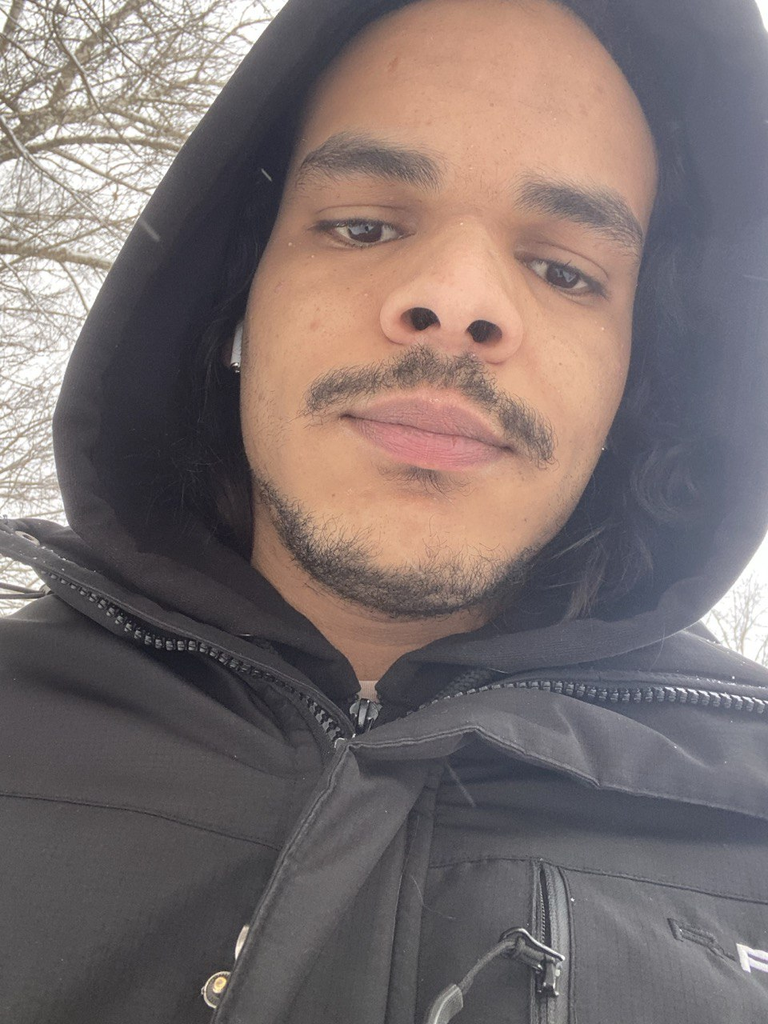

## Цель

Приобретение практических навыков по установке DVWA.

# Выполнение лабораторной работы

## 1.1

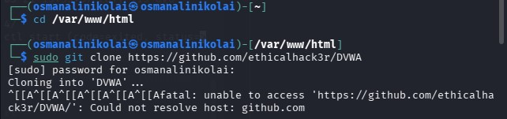

## 1.2

Повышаю права доступа к этой папке до 777

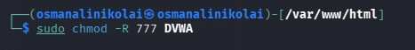

Изменение прав доступа

## 1.3

Чтобы настроить DVWA, нужно перейти в каталог `/dvwa/config`

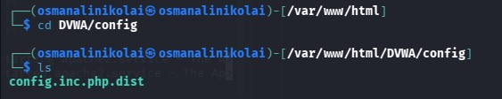

Перемещение по директориям

## 1.4

Создаем копию файла, используемого для настройки DVWA `config.inc.php.dist` с именем `config.inc.php`.

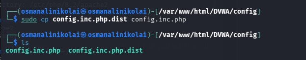

Создание копии файла

## 1.5

Изменяю данные об имени пользователя и пароле

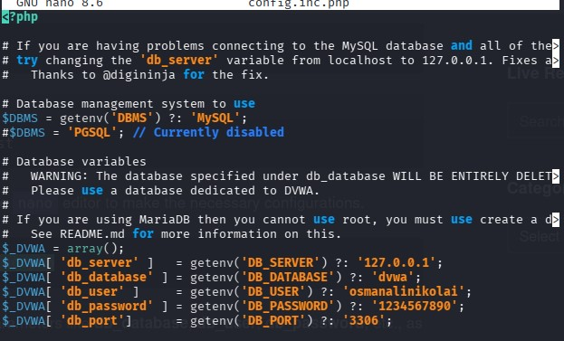

Редактирование файл

## 2.1

Запускаю mysql

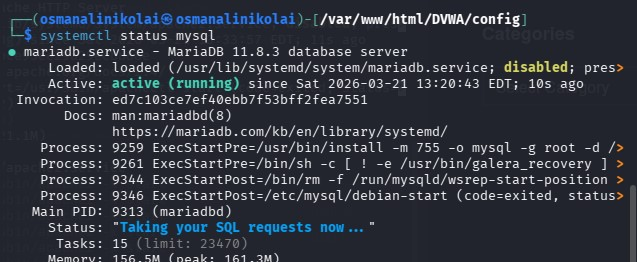

Запуск mysql

## 2.2

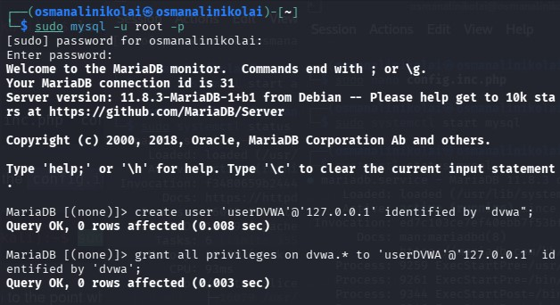

Авторизация в базе данных

## 2.3

Теперь нужно пользователю предоставить привилегии для работы с этой базой данных

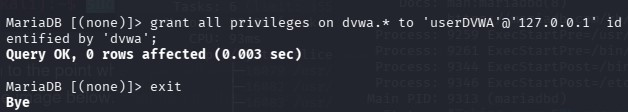

Изменение прав

## 3.1

Необходимо настроить сервер apache2, перехожу в соответствующую директорию

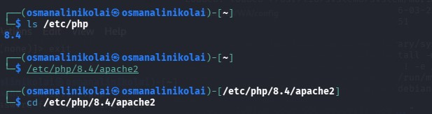

Перемещение между директориями

## 3.2

В файле параметры allow_url_fopen и allow_url_include должны быть поставлены как `On`

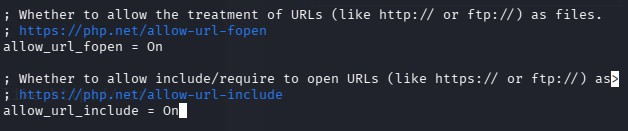

Редактирование файла

## 3.3

Запускаем службу веб-сервера apache и проверяем, запущена ли служба

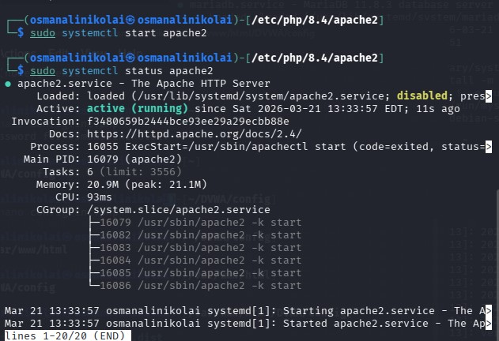

Запуск apche

## 4.1

Мы настроили DVWA, Apache и базу данных, поэтому открываем браузер и запускаем веб-приложение, введя 127.0.0/DVWA

[figure not shown]

Запуск веб-приложения

## 4.2

Прокручиваем страницу вниз и нажимем на кнопку `create\reset database`

[figure not shown]

“Создание базы данных”

## 4.3

Авторизуюсь с помощью предложенных по умолчанию данных

[figure not shown]

Авторизация

## 4.4

Оказываюсь на домшней странице веб-приложения, на этом установка окончена

[figure not shown]

Домашняя страница DVWA

## Вывод

Приобрела практические навыки по установке уязвимого веб-приложения DVWA.

# Спасибо за внимание